# Dpylr y ggplot

## 6. ¿Que condiciones climáticas serian ideales para nuestra demanda?(considere una función de densidad bivariable)

```r
plot(density((subset(df, season==1))$cnt),col="green",main="Densidades segun estacion")
lines(density((subset(df, season==2))$cnt),col="orange")
```

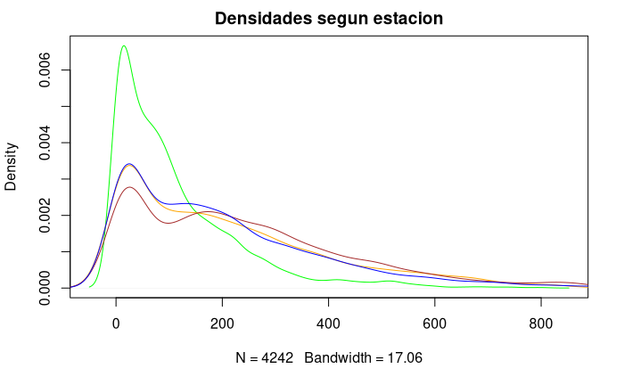

```r
lines(density((subset(df, season==3))$cnt),col="brown")
lines(density((subset(df, season==4))$cnt),col="blue")
```

## 7. Mueste una gráfica de la densidad de rentas.

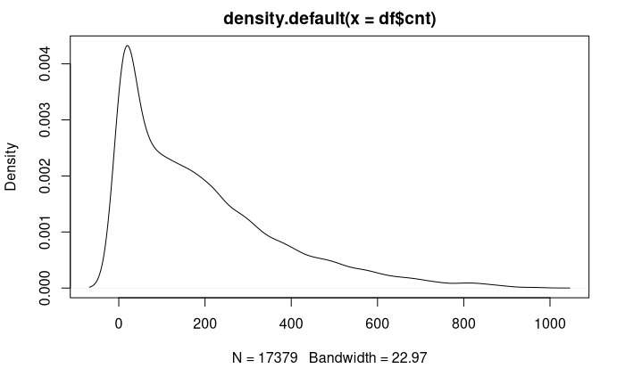

```r
plot(density(df$cnt))
```

## 8. Determine promedio de personas que rentan bicicletas y están registradas.

```r
paste("Proedio de personas que rentan bicicletas y estan registradas es",mean(df$registered))
```

```
[1] "Proedio de personas que rentan bicicletas y estan registradas es 153.786869209966"
```

### Promedio de renta de bicicletas por temporada.

```r
df %>%
  group_by(season) %>%
  summarise_at(vars(registered), list(registered = mean))
```

| season | registered |
| --- | --- |
| 1 | 96.82367 |
| 2 | 162.18349 |
| 3 | 185.72909 |
| 4 | 168.20203 |

## 9. Determine la mediana de personas que rentan bicicletas y no están registradas.

```r
paste(" La mediana de las personas que no estan resgistradas y rentan bicicletas es:",median(df$casual))
```

```
[1] " La mediana de las personas que no estan resgistradas y rentan bicicletas es: 17"
```

## 10. Deterimne la renta total, renta promedio por cada tipo de condición climática.

Reta Total por condicion climatica

```r
df %>% group_by(weathersit) %>% summarise(cnt = sum(cnt))
```

| weathersit | cnt |
| --- | --- |
| 1 | 2338173 |
| 2 | 795952 |
| 3 | 158331 |
| 4 | 223 |

Renta promedio por condicion climatica

```r
df %>%
  group_by(weathersit) %>%
  summarise_at(vars(cnt), list(cnt = mean))
```

| weathersit | cnt |
| --- | --- |
| 1 | 204.86927 |
| 2 | 175.16549 |
| 3 | 111.57928 |
| 4 | 74.33333 |

## 11. Determine y muestre una gráfica de barras de cada renta por tipo de temporada.

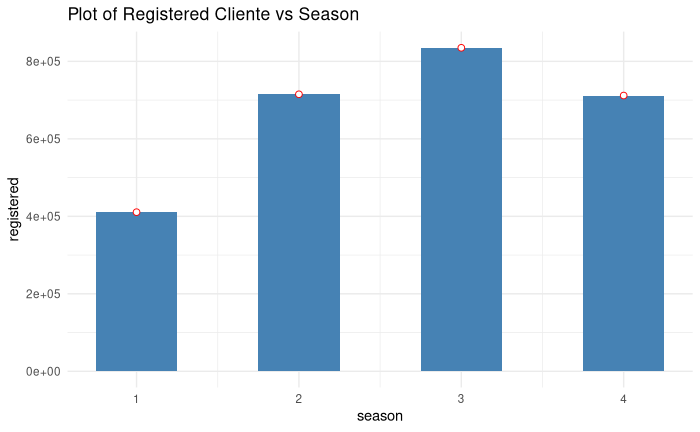

```r
library(ggplot2)

ggplot(data=df %>% group_by(season) %>% summarise(registered = sum(registered)), aes(x=season, y=registered)) +
  ggtitle("Plot of Registered Cliente vs Season ")+
  geom_bar(stat="identity", width = 0.5, fill="steelblue")+
  geom_point( size=2, shape=21, fill="white", colour="red") +
  theme_minimal()
```

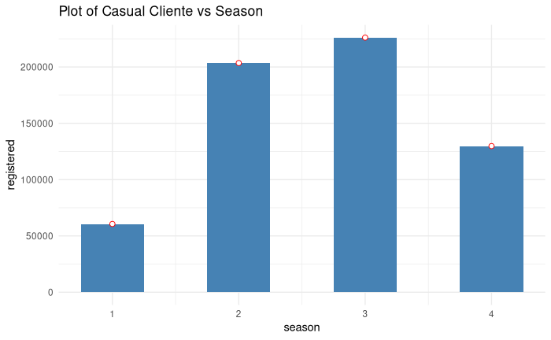

```r
ggplot(data=df %>% group_by(season) %>% summarise(registered = sum(casual)), aes(x=season, y=registered)) +
  ggtitle("Plot of Casual Cliente vs Season ")+
  geom_bar(stat="identity", width = 0.5, fill="steelblue")+
  geom_point( size=2, shape=21, fill="white", colour="red") +
  theme_minimal()
```